# B-4_Verteilungsvergleich

Michael Geuze

2024-05-19

```r
dist_comparison <- read.csv("Verteilungsvergleich.csv", sep=";", dec=",")


get_hist_data <- function(data, breaks = "Sturges", plot = FALSE) {
  # Create the histogram object
  hist_data <- hist(data, breaks = breaks, plot = plot)

  # Extract the breaks (bin edges), counts, and mids
  breaks <- hist_data$breaks
  counts <- hist_data$counts
  mids <- hist_data$mids

  # Create intervals from the breaks
  intervals <- data.frame(
    lower = breaks[-length(breaks)],    # All but the last break
    upper = breaks[-1],                 # All but the first break
    counts = counts,
    mids = mids
  )

  return(intervals)
}

get_interval_string <- function(lower, upper) {
  # Ensure lower and upper are of the same length and reasonable
  if(length(lower) != length(upper) || length(lower) == 0) {
    stop("Lower and upper bounds must be of the same non-zero length")
  }

  ret_str <- vector("character", length(lower))

  # Create the interval strings
  for (i in 1:(length(lower) - 1)) {
    ret_str[i] <- paste("[", lower[i], ",", upper[i], ")", sep = "")
  }

  ret_str[length(lower)] <- paste("[", lower[length(lower)], ",", upper[length(upper)], "]", sep = "")

  return (ret_str)
}

print_quantile_lines <- function(col = 2){
  abline(0.25, 0, lty = "dashed", col = col + 2)
  abline(0.5, 0, lty = "dashed", col = col + 4)
  abline(0.75, 0, lty = "dashed", col = col + 2)
}

plot_cumulative_barplot <- function(data_, names_, col_line = "red", col_plot = 1, col_qline = 4, xlab = "", ylab = "", main =""){
  barplot_positions <- barplot(
        data_,  # Positions holds the mid values.
        names.arg = names_,
        col = col_plot,
        xlab = xlab,
        ylab = ylab,
        main = main,
        space = 0
  )

# Plot the cumulative distribution line

  line_positions_x <- c(0, barplot_positions + (barplot_positions[2] - barplot_positions[1]) /2) # Create X coordinates. Assuming they are evenly spread
  par(new = TRUE)

  lines(x = line_positions_x,
        y = c(0, data_), # We are starting at coord x=0, y=0
        lty = 3,
        col = col_line)
  print_quantile_lines(col_qline)
}

get_mode <- function(v) {
  # Use table to get the frequency of each element
  freq_table <- table(v)

  # Find the maximum frequency
  max_freq <- max(freq_table)

  # Get the values with the maximum frequency
  mode_val <- as.numeric(names(freq_table)[freq_table == max_freq])

  return(mode_val)
}
```

## a)

### Häufigkeitstabelle

```r
cat("Würfel Häufigkeitstabelle:")
```

```
## Würfel Häufigkeitstabelle:
```

```r
würfel.tb <- table(dist_comparison$Wuerfel)
würfel.tb
```

```
##
## 1 2 3 4 5 6
## 5 9 7 5 8 6
```

Die anderen Merkmale sind reelwertige Zahlen, daher müssen diese zuvor in Klassen eingeteilt werden. So wäre eine Häufigkeitstabelle sinnlos.

```r
wartezeit_hist <- get_hist_data(dist_comparison$Wartezeit_min)
wartezeit.df <- data.frame(
  wartezeit_minuten = get_interval_string(wartezeit_hist$lower, wartezeit_hist$upper),
  anzahl = wartezeit_hist$counts)
cat("Häufikeitstabelle Minuten zwischen Vorbeifahrenden Autos")
```

```
## Häufikeitstabelle Minuten zwischen Vorbeifahrenden Autos
```

```r
wartezeit.df
```

```
##   wartezeit_minuten anzahl
## 1             [0,2)     18
## 2             [2,4)      7
## 3             [4,6)      8
## 4             [6,8)      3
## 5            [8,10)      2
## 6           [10,12)      1
## 7           [12,14)      0
## 8           [14,16]      1
```

```r
telefongespräch_länge <- get_hist_data(dist_comparison$Telgesprae_min)
telefongespräch.df <- data.frame(
  länge_des_gesprächs = get_interval_string(telefongespräch_länge$lower, telefongespräch_länge$upper),
  anzahl = telefongespräch_länge$counts)
cat("Häufikeitstabelle Minuten der Telefongespräche")
```

```
## Häufikeitstabelle Minuten der Telefongespräche
```

```r
telefongespräch.df
```

```
##   länge_des_gesprächs anzahl
## 1               [0,2)      2
## 2               [2,4)     32
## 3               [4,6)      5
## 4               [6,8)      0
## 5              [8,10)      0
## 6             [10,12)      0
## 7             [12,14)      0
## 8             [14,16]      1
```

```r
stiftlaenge_cm <- get_hist_data(dist_comparison$Stiftlaenge_cm)
stiftlaenge_cm.df <- data.frame(
  länge_des_stifts = get_interval_string(stiftlaenge_cm$lower, stiftlaenge_cm$upper),
  anzahl = stiftlaenge_cm$counts)
cat("Häufikeitstabelle Minuten der Telefongespräche")
```

[output not shown]

```r
stiftlaenge_cm.df
```

```
##   länge_des_stifts anzahl
## 1       [3.3,3.35)      2
## 2       [3.35,3.4)      9
## 3       [3.4,3.45)      5
## 4       [3.45,3.5)      3
## 5       [3.5,3.55)      9
## 6       [3.55,3.6)      6
## 7       [3.6,3.65)      2
## 8       [3.65,3.7)      3
## 9       [3.7,3.75]      1
```

### Häufigkeitsverteilung und Summenhäufigkeit

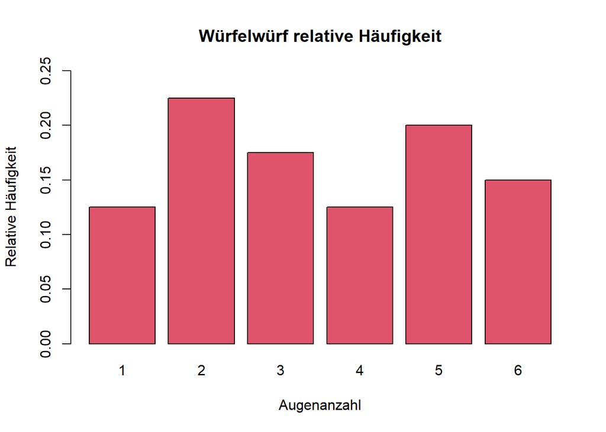

```r
# Farbzuweisungen für alle Plots
würfel.col = 2
wartezeit.col = 3
gespräche.col = 4
stiftlänge.col = 5

barplot(würfel.tb / sum(würfel.tb),
        ylim = c(0,0.25),
        ylab = "Relative Häufigkeit",
        xlab = "Augenanzahl",
        main = "Würfelwürf relative Häufigkeit",
        col = würfel.col
        )
```

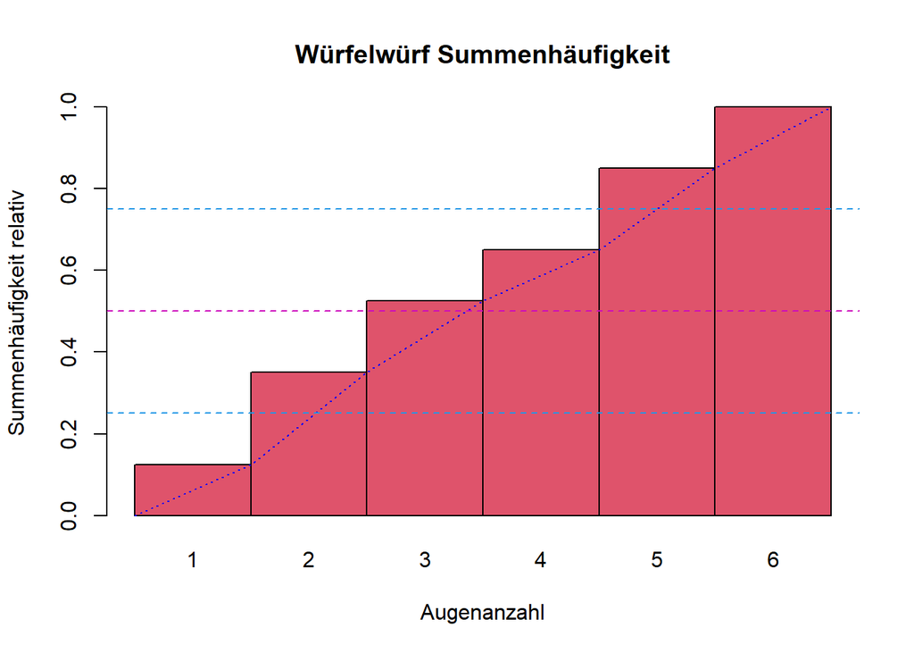

```r
plot_cumulative_barplot(
        data_ = cumsum(würfel.tb) / sum(würfel.tb),
        names_ = c(1:6),
        ylab = "Summenhäufigkeit relativ",
        xlab = "Augenanzahl",
        main = "Würfelwürf Summenhäufigkeit",
        col_plot = würfel.col,
        col_line = "blue"
        )

print_quantile_lines(würfel.col)
```

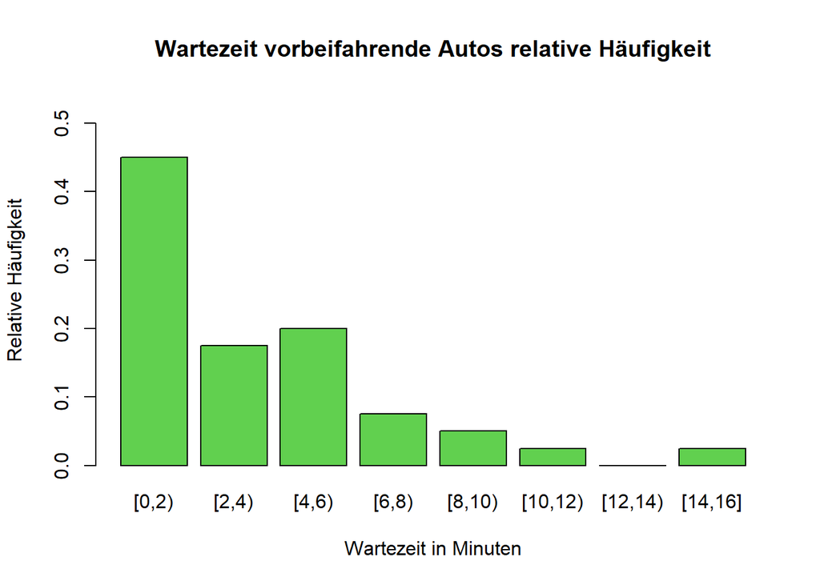

```r
barplot(wartezeit.df$anzahl / sum(wartezeit.df$anzahl),
        ylim = c(0,max(wartezeit.df$anzahl) / sum(wartezeit.df$anzahl) * 1.2),
        names.arg = wartezeit.df$wartezeit_minuten,
        ylab = "Relative Häufigkeit",
        xlab = "Wartezeit in Minuten",
        main = "Wartezeit vorbeifahrende Autos relative Häufigkeit",
        col = wartezeit.col
        )
```

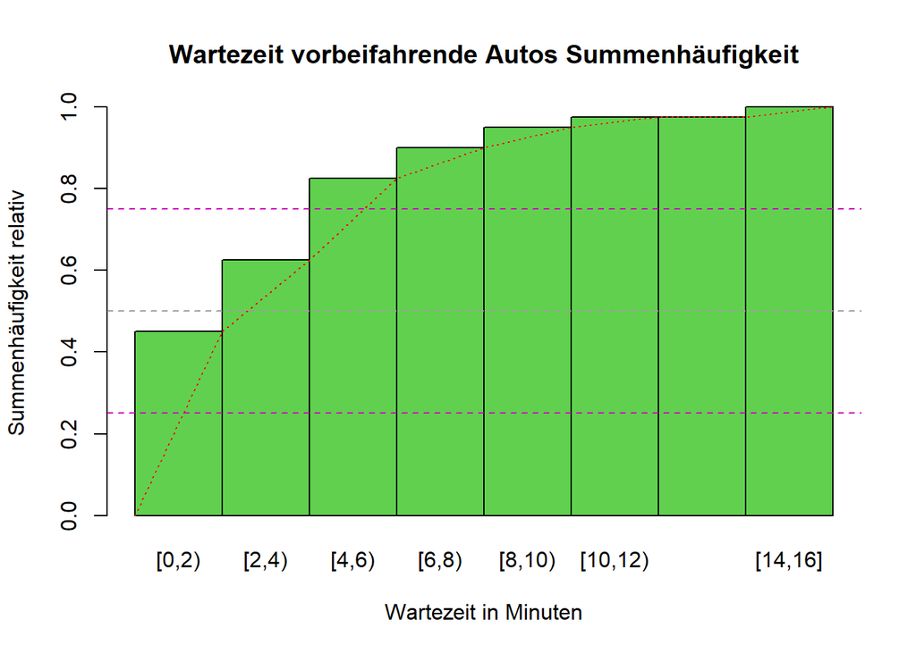

```r
plot_cumulative_barplot(
        data_ = cumsum(wartezeit.df$anzahl) / sum(wartezeit.df$anzahl),
        names_ = wartezeit.df$wartezeit_minuten,
        ylab = "Summenhäufigkeit relativ",
        xlab = "Wartezeit in Minuten",
        main = "Wartezeit vorbeifahrende Autos Summenhäufigkeit",
        col_plot = wartezeit.col,
        col_line = "red"
        )
```

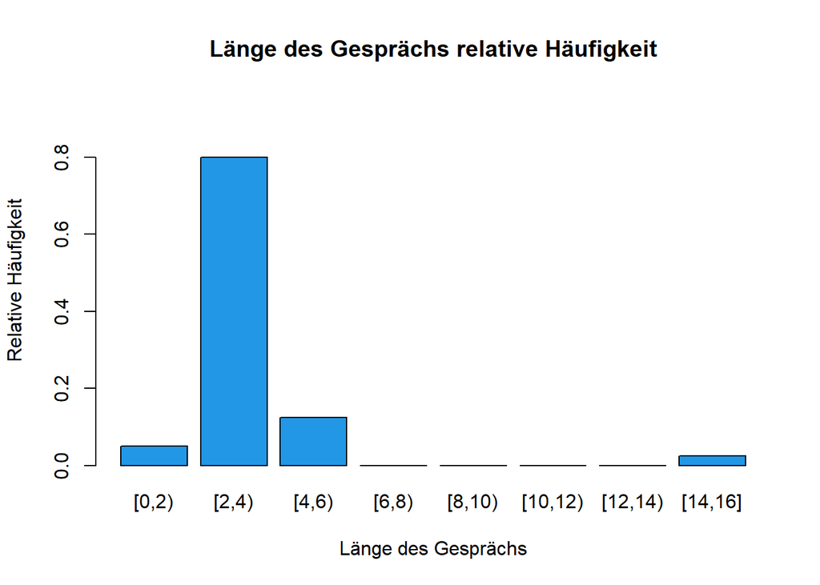

```r
barplot(telefongespräch.df$anzahl / sum(telefongespräch.df$anzahl),
        ylim = c(0,max(telefongespräch.df$anzahl) / sum(telefongespräch.df$anzahl) * 1.2),
        names.arg = telefongespräch.df$länge_des_gesprächs,
        ylab = "Relative Häufigkeit",
        xlab = "Länge des Gesprächs",
        main = "Länge des Gesprächs relative Häufigkeit",
        col = gespräche.col
        )
```

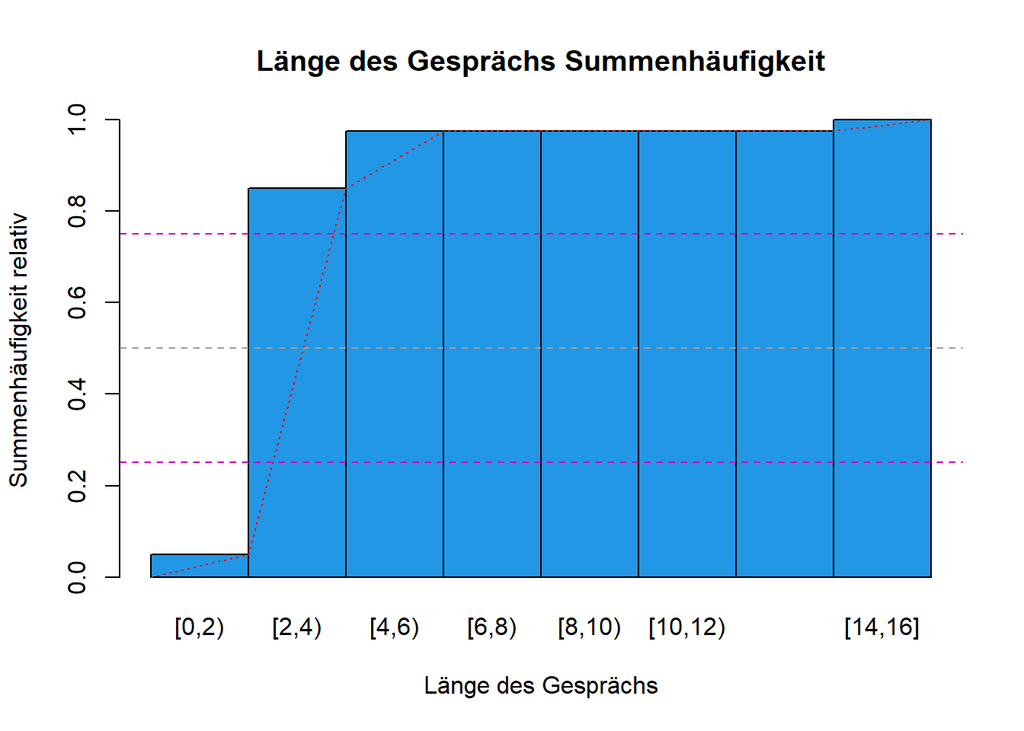

```r
plot_cumulative_barplot(
        data_ = cumsum(telefongespräch.df$anzahl) / sum(telefongespräch.df$anzahl),
        names_ =telefongespräch.df$länge_des_gesprächs,
        ylab = "Summenhäufigkeit relativ",
        xlab = "Länge des Gesprächs",
        main = "Länge des Gesprächs Summenhäufigkeit",
        col_plot = gespräche.col,
        col_line = "red"
        )
```

```r
stiftlaenge_cm.df$länge_des_stifts
```

```
## [1] "[3.3,3.35)" "[3.35,3.4)" "[3.4,3.45)" "[3.45,3.5)" "[3.5,3.55)"
## [6] "[3.55,3.6)" "[3.6,3.65)" "[3.65,3.7)" "[3.7,3.75]"
```

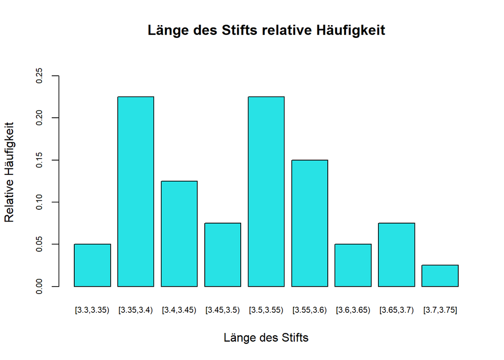

```r
par(cex.axis = 0.7)

barplot(stiftlaenge_cm.df$anzahl / sum(stiftlaenge_cm.df$anzahl),
        ylim = c(0,max(stiftlaenge_cm.df$anzahl) / sum(stiftlaenge_cm.df$anzahl) * 1.2),
        names.arg = stiftlaenge_cm.df$länge_des_stifts,
        ylab = "Relative Häufigkeit",
        xlab = "Länge des Stifts",
        main = "Länge des Stifts relative Häufigkeit",
        col = stiftlänge.col
        )
```

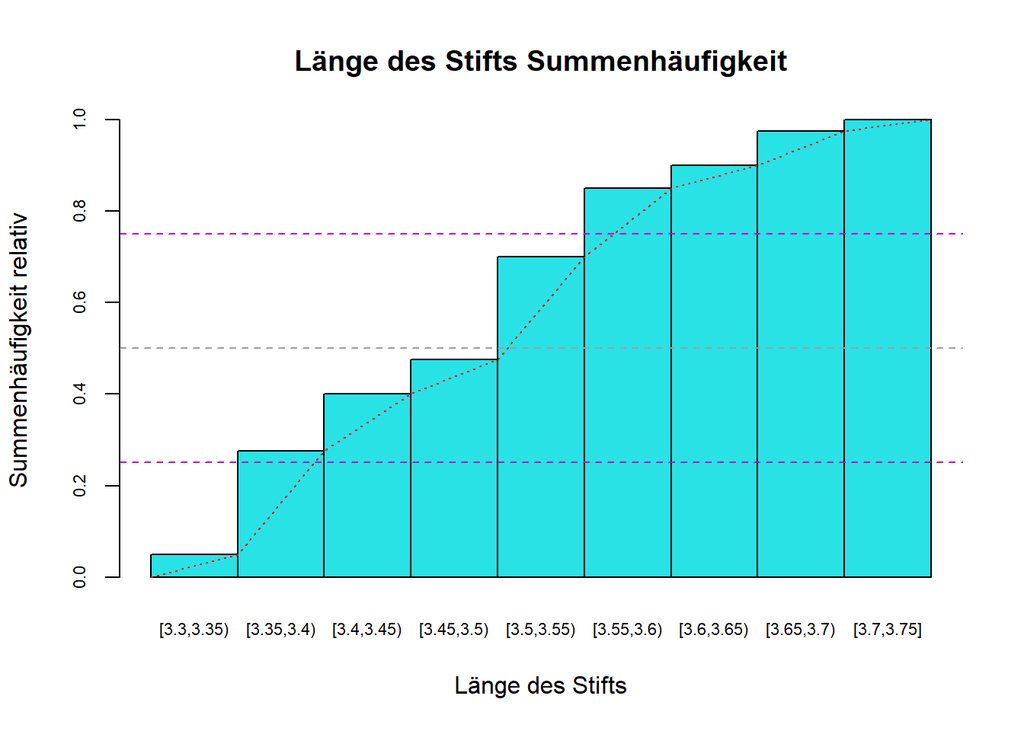

```r
plot_cumulative_barplot(
        data_ = cumsum(stiftlaenge_cm.df$anzahl) / sum(stiftlaenge_cm.df$anzahl),
        names_ = stiftlaenge_cm.df$länge_des_stifts,
        ylab = "Summenhäufigkeit relativ",
        xlab = "Länge des Stifts",
        main = "Länge des Stifts Summenhäufigkeit",
        col_plot = stiftlänge.col,
        col_line = "red"
        )
```

```r
par(cex.axis = 1)
```

## b)

Schätzung Würfel: Mittel: 3 Median: 3

Schätzung vorbeifahrende Autos: Mittel: 2,2 Median: 2,4

Schätzung Länge des Telefongesprächs: Mittel: 3 Median: 3,2

## c)

### Würfelwurf

```r
cat("Merkmalsausprägung unter derer 25% der Würfelwürfe sind", sort(dist_comparison$Wuerfel)[10])
```

```
## Merkmalsausprägung unter derer 25% der Würfelwürfe sind 2
```

### Wartezeit Autos

```r
cat("Merkmalsausprägung unter derer 25% der Messwerte sind", sort(dist_comparison$Wartezeit_min)[10], "min")
```

```
## Merkmalsausprägung unter derer 25% der Messwerte sind 0.62 min
```

### Länge Telefongespräche

```r
cat("Merkmalsausprägung unter derer 25% der Telefongespräche sind", sort(dist_comparison$Telgesprae_min)[10], "min")
```

```
## Merkmalsausprägung unter derer 25% der Telefongespräche sind 2.67 min
```

### Stiftlänge

```r
cat("Merkmalsausprägung unter derer 25% der Stiftlängen sind", sort(dist_comparison$Stiftlaenge_cm)[10], "cm")
```

```
## Merkmalsausprägung unter derer 25% der Stiftlängen sind 3.4 cm
```

## d)

### Würfelwurf

```r
cat("Modus", get_mode(dist_comparison$Wuerfel))
```

```
## Modus 2
```

```r
quantile(dist_comparison$Wuerfel)
```

```
##   0%  25%  50%  75% 100%
##    1    2    3    5    6
```

```r
cat("Min", min(dist_comparison$Wuerfel), "Max", max(dist_comparison$Wuerfel) )
```

```
## Min 1 Max 6
```

```r
cat("Spannweite", max(dist_comparison$Wuerfel) - min(dist_comparison$Wuerfel))
```

```
## Spannweite 5
```

```r
cat("Mittelwert", mean(dist_comparison$Wuerfel))
```

```
## Mittelwert 3.5
```

```r
cat("Standardabweichung", sd(dist_comparison$Wuerfel))
```

```
## Standardabweichung 1.679438
```

```r
cat("Mittlere Absolute Abweichung", sum(abs(mean(dist_comparison$Wuerfel) - dist_comparison$Wuerfel)) / length(dist_comparison$Wuerfel))
```

```
## Mittlere Absolute Abweichung 1.475
```

#### Bewertung:

Die Ereignisse sind gleichverteilt. Der Mittelwert ist genau in der Mitte der Spannweite. Dazu gibt es noch eine recht kleine Standardabweichung.

### Info Klassifizierte Daten

```r
cat("Modus", wartezeit.df$wartezeit_minuten[wartezeit.df$anzahl == max(wartezeit.df$anzahl)])
```

```
## Modus [0,2)
```

```r
cat("Q25", sort(dist_comparison$Wartezeit_min)[10])
```

```
## Q25 0.62
```

```r
cat("Q50", sort(dist_comparison$Wartezeit_min)[20])
```

```
## Q50 2.569
```

```r
cat("Q75", sort(dist_comparison$Wartezeit_min)[30])
```

```
## Q75 5.623
```

```r
cat("Interquartilabstand", sort(dist_comparison$Wartezeit_min)[30] - sort(dist_comparison$Wartezeit_min)[10])
```

```
## Interquartilabstand 5.003
```

```r
cat("Min", sort(dist_comparison$Wartezeit_min)[1], "Max", sort(dist_comparison$Wartezeit_min)[40] )
```

```
## Min 0.102 Max 15.788
```

```r
cat("Spannweite", sort(dist_comparison$Wartezeit_min)[40] - sort(dist_comparison$Wartezeit_min)[1])
```

```
## Spannweite 15.686
```

```r
cat("Mittelwert", mean(dist_comparison$Wartezeit_min))
```

```
## Mittelwert 3.5
```

```r
cat("Standardabweichung", sd(dist_comparison$Wartezeit_min))
```

```
## Standardabweichung 3.493427
```

```r
cat("Mittlere Absolute Abweichung", sum(abs(mean(dist_comparison$Wartezeit_min) - dist_comparison$Wartezeit_min)) / length(dist_comparison$Wartezeit_min))
```

```
## Mittlere Absolute Abweichung 2.66165
```

#### Bewertung:

Maximalwert und Spannweite sind bedeutend höher als etwa der Modus oder der Mittelwert. Man kann in der Grafik auch schön erkennen, dass hier im Intervall [0,2) etwa 45% der Messwerte liegen. Es handelt sich hierbei um die Exponentailverteilung. Daher ist jeder Messwert der größer wird, noch unwahrscheinlicher. Wenn man hier eine Exponentailfunktion mit den Richtigen Parametern einlegen würde, so wäre das die Einhüllende der Funktionswerte.

### Länge Telefongespräche

```r
cat("Modus", telefongespräch.df$länge_des_gesprächs[telefongespräch.df$anzahl == max(telefongespräch.df$anzahl)])
```

```
## Modus [2,4)
```

```r
cat("Q25", sort(dist_comparison$Telgesprae_min)[10])
```

```
## Q25 2.67
```

```r
cat("Q50", sort(dist_comparison$Telgesprae_min)[20])
```

```
## Q50 3.29
```

```r
cat("Q75", sort(dist_comparison$Telgesprae_min)[30])
```

```
## Q75 3.79
```

```r
cat("Interquartilabstand", sort(dist_comparison$Telgesprae_min)[30] - sort(dist_comparison$Telgesprae_min)[10])
```

```
## Interquartilabstand 1.12
```

```r
cat("Min", sort(dist_comparison$Telgesprae_min)[1], "Max", sort(dist_comparison$Telgesprae_min)[40] )
```

```
## Min 1.62 Max 14.21
```

```r
cat("Spannweite", sort(dist_comparison$Telgesprae_min)[40] - sort(dist_comparison$Telgesprae_min)[1])
```

```
## Spannweite 12.59
```

```r
cat("Mittelwert", mean(dist_comparison$Telgesprae_min))
```

```
## Mittelwert 3.49975
```

```r
cat("Standardabweichung", sd(dist_comparison$Telgesprae_min))
```

```
## Standardabweichung 1.882077
```

```r
cat("Mittlere Absolute Abweichung", sum(abs(mean(dist_comparison$Telgesprae_min) - dist_comparison$Telgesprae_min)) / length(dist_comparison$Telgesprae_min))
```

```
## Mittlere Absolute Abweichung 0.8622
```

### Länge der Stifte

```r
cat("Modus", stiftlaenge_cm.df$länge_des_stifts[stiftlaenge_cm.df$anzahl == max(stiftlaenge_cm.df$anzahl)])
```

```
## Modus [3.35,3.4) [3.5,3.55)
```

```r
cat("Q25", sort(dist_comparison$Stiftlaenge_cm)[10])
```

```
## Q25 3.4
```

```r
cat("Q50", sort(dist_comparison$Stiftlaenge_cm)[20])
```

```
## Q50 3.51
```

```r
cat("Q75", sort(dist_comparison$Stiftlaenge_cm)[30])
```

```
## Q75 3.57
```

```r
cat("Interquartilabstand", sort(dist_comparison$Stiftlaenge_cm)[30] - sort(dist_comparison$Stiftlaenge_cm)[10])
```

```
## Interquartilabstand 0.17
```

```r
cat("Min", sort(dist_comparison$Stiftlaenge_cm)[1], "Max", sort(dist_comparison$Stiftlaenge_cm)[40] )
```

```
## Min 3.34 Max 3.75
```

```r
cat("Spannweite", sort(dist_comparison$Stiftlaenge_cm)[40] - sort(dist_comparison$Stiftlaenge_cm)[1])
```

```
## Spannweite 0.41
```

```r
cat("Mittelwert", mean(dist_comparison$Stiftlaenge_cm))
```

```
## Mittelwert 3.5
```

```r
cat("Standardabweichung", sd(dist_comparison$Stiftlaenge_cm))
```

```
## Standardabweichung 0.1059511
```

```r
cat("Mittlere Absolute Abweichung", sum(abs(mean(dist_comparison$Stiftlaenge_cm) - dist_comparison$Stiftlaenge_cm)) / length(dist_comparison$Stiftlaenge_cm))
```

```
## Mittlere Absolute Abweichung 0.0875
```

#### Bewertung

Der Grafik nach, könnten hier 2 überlagerte Normalverteilungen im Hintergrund stehen. Mann sieht 2 große Peaks in den Intervallen [3.35, 3.4) und [3.5, 3.55). Es gibt auch 2 Modis mit der verwendeten Klassifizierung. Es könnte sein, dass hier die Stift von 2 unterschiedlichen Produktionslinien oder Werkzeugen vermessen wurden. Das würde die doch recht große Streuung und die 2 Peaks erklären.

## e)

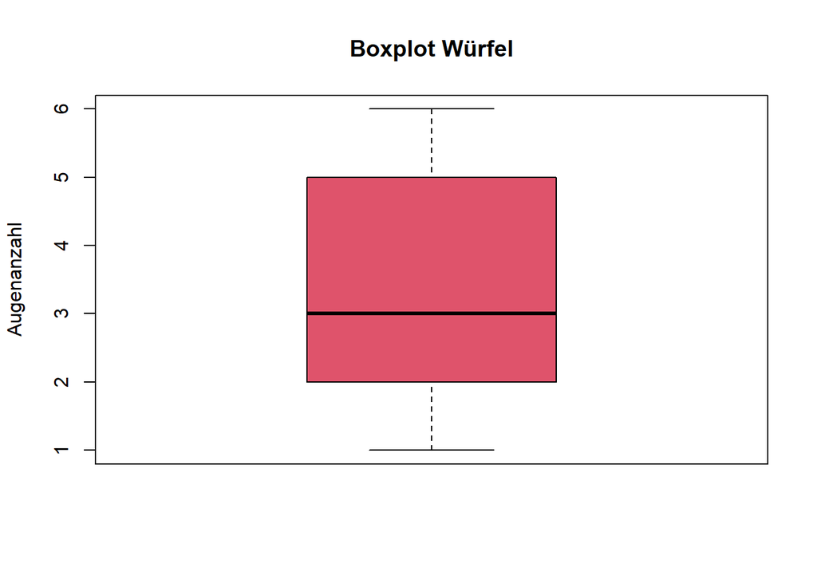

```r
boxplot(dist_comparison$Wuerfel,
        main = "Boxplot Würfel",
        col = würfel.col,
        ylab = "Augenanzahl")
```

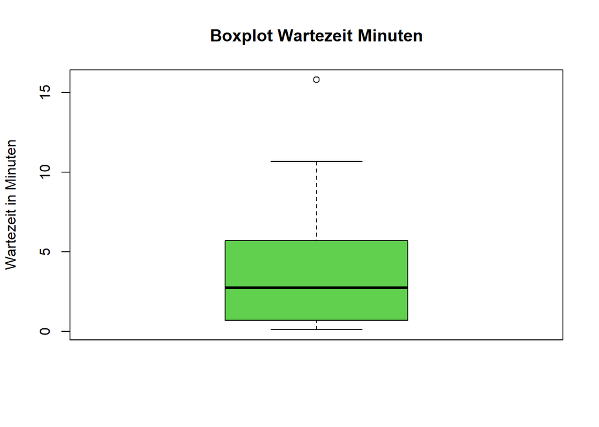

```r
boxplot(dist_comparison$Wartezeit_min,
        main = "Boxplot Wartezeit Minuten",
        ylab = "Wartezeit in Minuten",
        col = wartezeit.col)
```

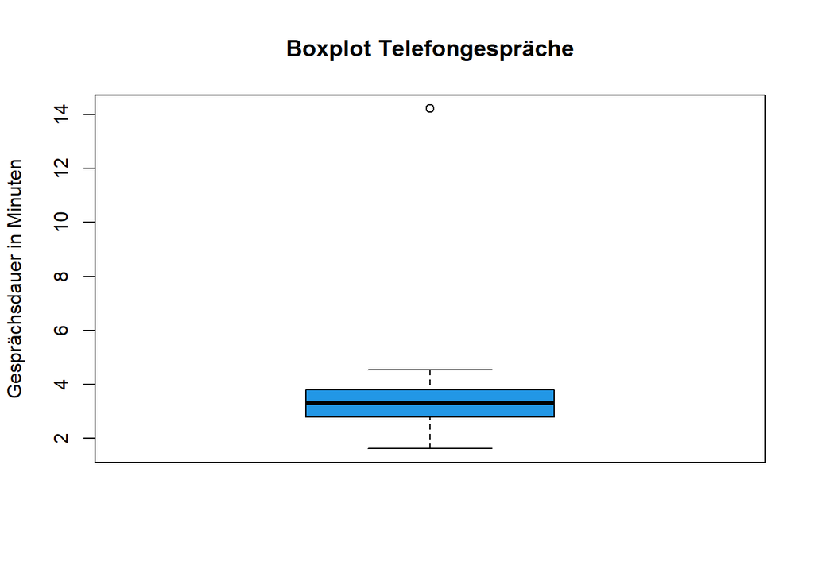

```r
boxplot(dist_comparison$Telgesprae_min,
        main = "Boxplot Telefongespräche",
        ylab = "Gesprächsdauer in Minuten",
        col = gespräche.col)
```

Zur Übersicht, hier noch ein Boxplot ohne den weit entfernten Ausreißer:

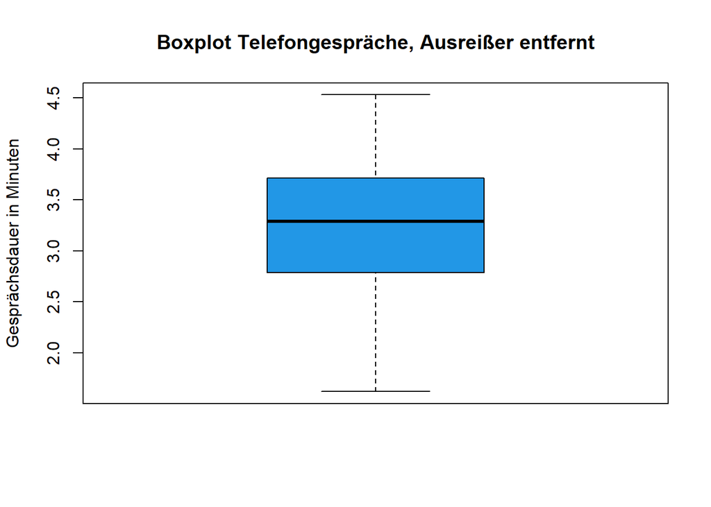

```r
boxplot(sort(dist_comparison$Telgesprae_min)[1:39],
        main = "Boxplot Telefongespräche, Ausreißer entfernt",
        ylab = "Gesprächsdauer in Minuten",
        col = gespräche.col)
```

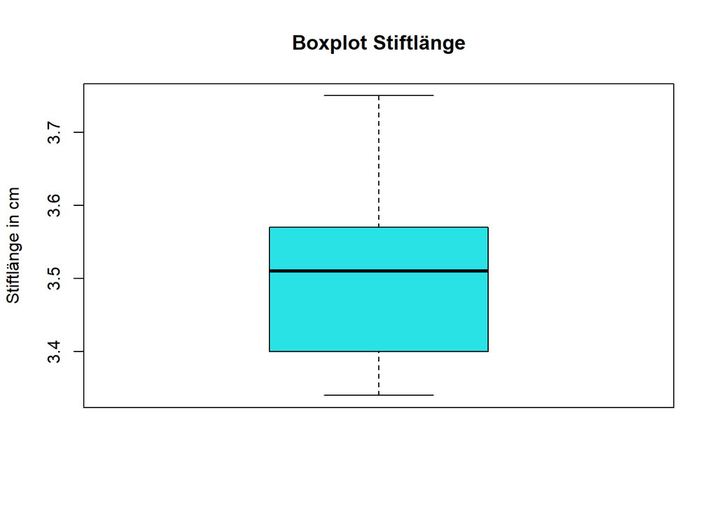

```r
boxplot(dist_comparison$Stiftlaenge_cm,
        main = "Boxplot Stiftlänge",
        ylab = "Stiftlänge in cm",
        col = stiftlänge.col)
```